# Distribution of maximum in random walks

Evgeni Ovcharov

August 12, 2017

### Introduction

It is not hard to see that the maximum and minimum of a simple, symmetric random walk have the same probability distribution. Indeed, exchanging each outcome with its dual obtains a pair of random walks whose graphs are mirror images of each other. Furthermore, considering for each random walk the walk that is obtained from it by taking each step in reverse order, we see that the distribution of maximum must be symmetric with respect to its midpoint. It may, however, be quite non-intuitive the fact that both the maximum and minimum occur with highest probability at the two endpoints of the walk.

The maximum of a random walk is intimately related with the combinatorial theory of positive random walks. Indeed, every maximum induces a nonnegative random walk to its left and a nonpositive random walk to its right. The main combinatorial facts concerning positive random walks can be deduced with the so called *reflection principle*. Here we present an interesting problem that illustrates well the subject of positive random walks and the related combinatorial techniques.

### Problem

Prove that the probability distribution of maximum in a finite, simple, symmetric random walk has its maximal probability at the two endpoints of the walk. Here by a simple, symmetric random walk we understand a walk that is generated by a series of Bernoulli trials with outcomes -1 and 1 that are equally likely.

### Reflection Principle

Before we continue with the solution we need to revise the important reflection principle for counting paths. A *path* is a continuous piecewise linear curve in $\mathbb R^2$ consisting of a finite union of segments of the form $[(i, j),(i + 1, j + 1)]$ or $[(i, j),(i + 1, j − 1)]$ where $i$, $j$ are integers. A path has an origin $(a, b)$ and an endpoint $(c, d)$ which are points on the curve with integer coordinates satisfying $a \leq i \leq c$ for all $(i, j)$ on the curve. The number $c-a$ is the *length* of the path.

The principle holds that there is a bijection between the paths starting at position $(0,a)$ and ending at position $(n,b)$ such that they touch or cross the line $y=0$, where $a,b\geq0$, and the paths that start at position $(0,-a)$ and end at position $(n,b)$. The principle is illustrated in Figure 1 below.

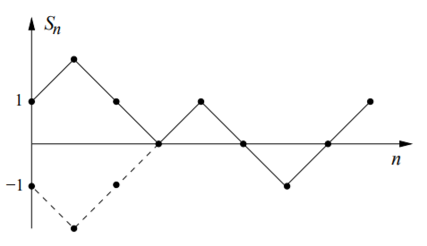

Figure 1. Reflection Principle

#### Counting paths

The number of paths starting at $(0,a)$ and ending at $(n, b)$ is
$$\binom n {(n-(b-a))/2},$$
provided that $n-(b-a)$ is even, or zero otherwise. Indeed, notice that such paths exist if we can solve the equation $n=2x+(b-a)$ for some nonnegative integer $x$. Specifically, the solution $x = (n-(b-a))/2$ is an integer precisely when $n-(b-a)$ is even. To obtain all such paths we need to choose $x$ places where the path is going up out of $n$ places, thus giving the above result. For all remaining other places the direction of the path is fixed: down for the remaining $x$ steps, and up or down, depending on whether $b-a>0$ or $b-a<0$, respectively, for the remaining $b-a$ steps.

The number of paths starting at $(0,a)$ and ending at $(n,b)$ such that they touch or cross the line $y=0$, where $a,b\geq0$, is equal to
$$\binom n {(n-(b+a))/2}.$$
If the bottom number in the above binomial coefficient is ether fractional or negative, we interpret the coefficient to mean zero. The claim follows directly from the reflection principle.

The number of nonnegative paths starting at $(0,0)$ of length $2n$ is
$$\binom {2n} n.$$
A path is *nonnegative/positive* if the second coordinate of all its subsequent nodes after the origin is nonnegative/positive. Notice that if a nonnegative path starting at $(0,0)$ and ending at $(n,b)$ has an odd length $n$, then we must have that $b$ is odd, and hence $b>0$. This follows from the fact that the coordinate pairs $(i,j)$ in a path have the property that the sum $i+j$ has the same oddity for all coordinate pairs. Hence a nonnegative path of odd length can be continued arbitrarily for one more step and it will still be a nonnegative path. Therefore, it is enough to find only the number of nonnegative paths of even length. (Those of odd length $n$ will be precisely one half of the nonnegative paths of even length $n+1$.) The above result is obtained as follows. Using the reflection principle with axis $y=-1$, we obtain that the number of nonnegative paths starting at (0,0) and ending at (2n, 0) is
$$\binom {2n} n - \binom {2n} {n-1}.$$
Similarly, the number of all nonnegative paths starting at (0,0) and ending at (2n, 2k), for $0<k<n$, is
$$\binom {2n} {n-k} - \binom {2n} {n-k-1}.$$
Summing for all $k=0,1,\dots,n-1$, we obtain a telescoping sum
$$\sum_{k=0}^{n-1} \left(\binom {2n} {n-k} - \binom {2n} {n-k-1}\right) = \binom {2n} n - 1$$
in which all intermediate terms cancel. Taking into account that for $k=n$, there is only one path connecting $(0,0)$ and $(2n,2n)$, obviously nonnegative, the result follows.

The number of positive paths starting at $(0,0)$ of length $2n$ is
$$\frac 1 2 \binom {2n} n.$$
The claim may be shown in the following two ways. First, we may count the positive paths starting at $(1,1)$ of length $2n-1$ reasoning as above and applying the reflection principle for the line $y=0$. The second way is as follows. Again we need to count only the positive paths starting at $(1,1)$ of length $2n-1$. Their number is equal to the nonnegative paths starting at $(0,0)$ of length $2n-1$. But as discussed earlier, extending such a path arbitrarily for one more step, we again obtain a nonnegative path, but of length $2n$. Since such an extension may be done in precisely two ways, the result follows.

### Solution of the problem

$$A_k = \{X_1\geq0, X_1+X_2\geq0, \dots, X_1+\cdots+X_k\geq0\},\\
B_{n-k} = \{X_{k+1}\leq0, X_{k+1} + X_{k+2}\leq0, \dots, X_{k+1} + \cdots + X_{n}\leq0\},$$
for $0< k < n$. The cases for which the maximum occurs at $k=0$ and $k=n$ correspond to the single events $B_n$ and $A_n$, respectively. Notice that $A_k$ and $B_{n-k}$ are independent for $0< k < n$. Thus we need to find the maximum among the probabilities
$$P(B_n), P(A_1)P(B_{n-1}), \dots, P(A_{n-1})P(B_1), P(A_n).$$
Notice that due to symmetry we have $P(A_i)=P(B_i)$, for $i=1,\dots,n$. The solution will be finished if we show that
$$\begin{equation}
P(A_n) > P(A_k) P(A_{n-k}), \label{eq: prob}
\end{equation}$$
for any $k = 1,...,n-1$. Below are presented three different ways of proving that inequality.

#### Proof 1

The reflection principle allows us to find directly the probabilities in $\eqref{eq: prob}$. First, notice that $S_i$ takes even values for $i$ even and odd values for $i$ odd. It follows that $P(A_1)=P(A_2)$, $P(A_3)=P(A_4)$, and so on. Hence, without loss of generality we may assume that $n$ and $k$ are even numbers. We have
$$P(A_n) = {\binom n {n/2}} / {2^{n}}, \qquad P(A_k)P(A_{n-k}) = {\binom k {k/2} \binom {n-k} {(n-k)/2}} / {2^{n}},$$
for $0<k<n$. The binomial coefficient
$$\displaystyle \binom n {n/2}$$
gives us the number of ways we may select $n/2$ objects out of a group of $n$ objects, while the product
$$\binom k {k/2} \binom {n-k} {(n-k)/2}$$
gives us the same, but with the restriction that the group of $n$ objects is split into two subgroups – one with $k$ and one with $n-k$ elements – and we must draw $k/2$ elements from the first subgroup and $(n-k)/2$ elements from the second subgroup. Clearly, the first, unrestricted way of choosing elements will give us more combinations than the second, restricted way. This furnishes the proof.

#### Proof 2

Our next idea of proving $\eqref{eq: prob}$ is based on the observation that among the nonnegative walks of length $n$, the part of those which return to zero at step $n$ form a monotonically decreasing sequence with $n$. Again, it is enough to consider only $n$ and $k$ even. We have
$$P(A_n) = P(A_{n-1}| A_{n-2}) P(A_{n-2}|A_{n-3}) \cdots P(A_2|A_1)P(A_1).$$
Since $P(A_{i+1}|A_i)$ = 1, for $i$ odd, the above factorization reduces to

$$\begin{equation}
P(A_n) = P(A_{n-1}| A_{n-2}) P(A_{n-3}|A_{n-4}) \cdots P(A_3|A_2)P(A_1), \label{eq: factor}
\end{equation}$$

where $n$ is even. The proof will follow if we show that the sequence $P(A_{i+1}|A_i)$, for $i$ even, is strictly monotone increasing. Indeed, notice that the terms on both sides of inequality $\eqref{eq: prob}$ will produce an equal number of factors of the form $\eqref{eq: factor}$, but those on the left will reach bigger indices.

The key identity to notice is

$$P(A_{2m+1}| A_{2m}) = P(S_{2m} > 0 | A_{2m}) + \frac 1 2 P(S_{2m} = 0 | A_{2m})\\
= 1 - \frac 1 2 P(S_{2m} = 0 | A_{2m}),$$
as $P(S_{2m} > 0 | A_{2m}) + P(S_{2m} = 0 | A_{2m}) = 1$. Thus, as stated in the beginning, it will be enough to show that the probabilities $P(S_{2m} = 0 | A_{2m})$ are monotonically decreasing. Notice first that the number of paths in the event $\{S_{2m} = 0\}$ are $\begin{pmatrix} 2m\\ m\end{pmatrix}$. Using the reflection principle we find out that out of these paths precisely $\begin{pmatrix} 2m\\ m-1\end{pmatrix}$ meet or cross the line $y=-1$. And finally, using the fact that there are $\begin{pmatrix} 2m\\ m\end{pmatrix}$ paths in the event $A_{2m}$, we find out that the probabilities
$$P(S_{2m} = 0 | A_{2m}) = \frac{\begin{pmatrix} 2m\\ m\end{pmatrix} - \begin{pmatrix} 2m\\ m-1\end{pmatrix}}{\begin{pmatrix} 2m\\ m\end{pmatrix}} = \frac 1 {m+1}$$
are strictly monotone decreasing with $m$. Thus the claim is proved.

#### Proof 3

Inequality $\eqref{eq: prob}$ may be shown directly, relying only on symmetry and conditional probability arguments. The key idea is to consider the factorization
$$P(A_n) = P(A_k) P(S_{k+1}\geq0,\dots, S_n\geq0| S_1\geq0,\dots, S_k\geq0).$$
Due to the independence of each trial, the conditional probability in the last expression is equivalent to the probability
$$P(S_{1}\geq0,\dots, S_{n-k}\geq0| S_0\geq0)$$
of a random walk that has a nonnegative start (with nonzero probability of a positive start). Since this is greater than the probability $P(A_{n-k})$ of the same random walk starting at zero, the claim follows.

### Conclusion

The most elegant way of proving inequality $\eqref{eq: prob}$ is perhaps the third one as it only relies on intrinsic symmetries of the problem. The other two proofs, however, better investigate the connection between the maximum of a random walk and the combinatorial theory of positive random walks. Thanks to the reflection principle we found out that the longer a random walk remains nonnegative, the higher the probability that it will remain nonnegative for the next few steps, and the lesser the probability that it will return to zero. This, perhaps, offers the most intuitive explanation of why the maximum of a random walk occurs with highest probability at the two endpoints of the walk. Furthermore, the second solution also indicates that the probability mass function of the distribution of maximum has the shape of a symmetric, convex curve.